# CELLxGENE Census: Query 60M Cells and Export to scverse

## Introduction

[CELLxGENE Census](https://chanzuckerberg.github.io/cellxgene-census/) provides programmatic access to over 60 million cells from hundreds of publicly deposited datasets. The [cellxgene.census](https://chanzuckerberg.github.io/cellxgene-census/r/index.html) R package exposes this corpus through TileDB-SOMA, enabling cell-type- and tissue-specific queries that return a ready-to-use Seurat object – no manual download of individual datasets required.

This article queries CD4+ T cells from peripheral blood, runs a standard Seurat analysis, and exports the result to h5ad for use in Python’s scverse ecosystem via scConvert.

## 1 Prerequisites

The Census packages are not on CRAN; install them from their respective R-universes.

```r
install.packages(
  "tiledb",
  repos = c("https://tiledb-inc.r-universe.dev",
            "https://cloud.r-project.org")
)
install.packages(
  "tiledbsoma",
  repos = c("https://tiledb-inc.r-universe.dev",
            "https://cloud.r-project.org")
)
install.packages(
  "cellxgene.census",
  repos = c("https://chanzuckerberg.r-universe.dev",
            "https://cloud.r-project.org")
)
```

## 2 Open Census and query CD4 T cells

`open_soma()` opens a connection to the stable Census release without downloading data locally. `get_seurat()` executes a server-side filter and streams only the matching cells and their expression values.

```r
suppressPackageStartupMessages(library(cellxgene.census))

t0 <- proc.time()

census <- open_soma(census_version = "stable")

cd4_raw <- get_seurat(
  census,
  organism = "Homo sapiens",
  obs_value_filter = paste(
    "cell_type == 'CD4-positive, alpha-beta T cell'",
    "& tissue_general == 'blood'",
    "& is_primary_data == True"
  ),
  obs_column_names = c("cell_type", "donor_id", "dataset_id",
                       "sex", "disease", "tissue_general"),
  var_column_names = c("feature_id", "feature_name")
)

census$close()

counts    <- GetAssayData(cd4_raw, assay = "RNA", layer = "counts")
rownames(counts) <- make.unique(cd4_raw[["RNA"]][[]]$feature_name)
cd4       <- CreateSeuratObject(counts = counts, meta.data = cd4_raw[[]])
rm(cd4_raw, counts)

query_time <- (proc.time() - t0)[["elapsed"]]
cat(sprintf("Queried %d cells from Census in %.1fs\n", ncol(cd4), query_time))
```

```
#> Queried 964175 cells from Census in 2004.1s
```

## 3 Seurat analysis pipeline

```r
set.seed(42L)
cd4 <- NormalizeData(cd4, verbose = FALSE)
cd4 <- FindVariableFeatures(cd4, nfeatures = 2000L, verbose = FALSE)
cd4 <- ScaleData(cd4, verbose = FALSE)
cd4 <- RunPCA(cd4, npcs = 30L, verbose = FALSE)
cd4 <- RunUMAP(cd4, dims = 1:20, verbose = FALSE)
cd4 <- FindNeighbors(cd4, dims = 1:20, verbose = FALSE)
cd4 <- FindClusters(cd4, resolution = 0.5, verbose = FALSE)
```

## 4 Visualizations

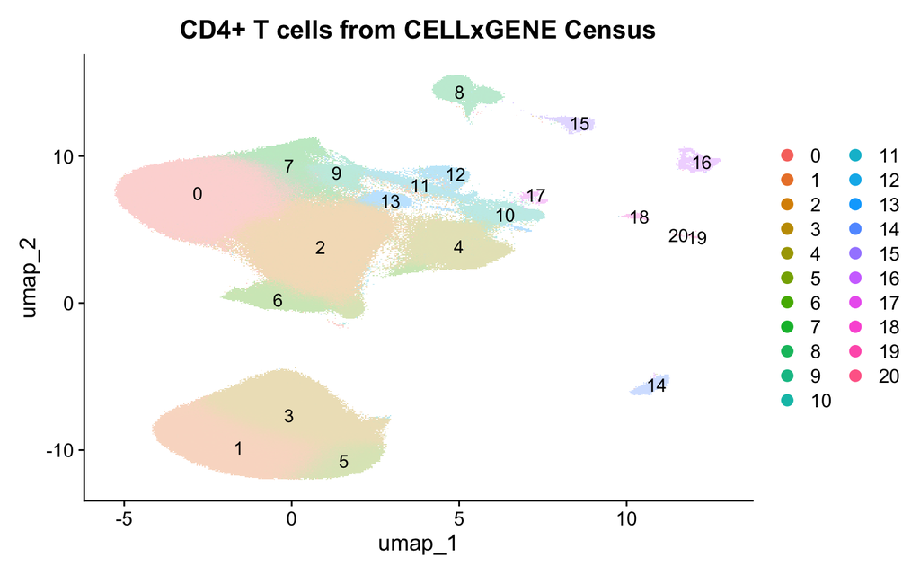

UMAP of CD4+ T cells from CELLxGENE Census, coloured by cluster.

```r
DimPlot(cd4, label = TRUE, label.size = 4, pt.size = 0.3) +
  ggtitle("CD4+ T cells from CELLxGENE Census") +
  theme(plot.title = element_text(hjust = 0.5))
```

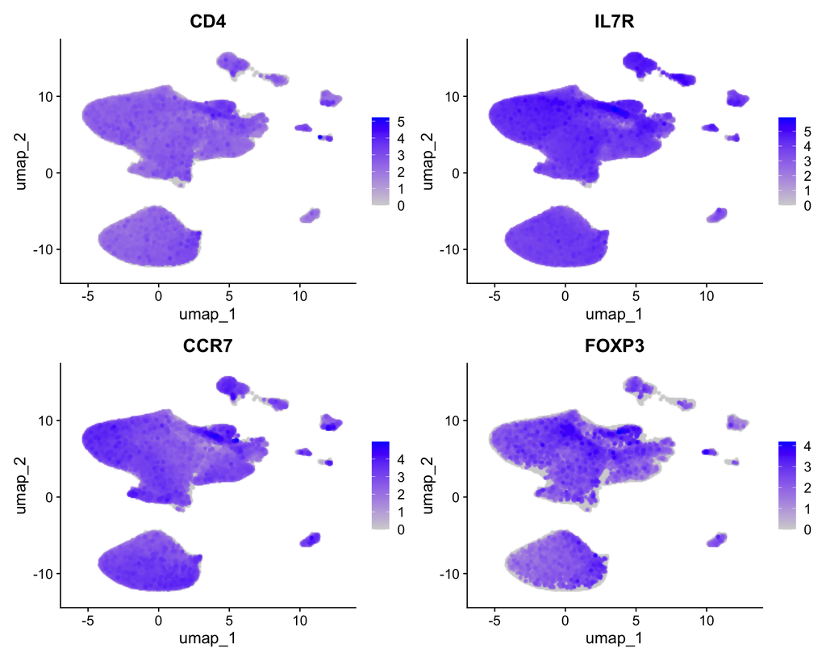

Canonical CD4 T cell marker genes.

```r
markers <- intersect(c("CD4", "IL7R", "CCR7", "FOXP3"), rownames(cd4))
if (length(markers) >= 1L) {
  FeaturePlot(cd4, features = markers, ncol = 2, pt.size = 0.3, order = TRUE)
}
```

[figure not shown]

Disease composition of the CD4 T cell query result.

```r
disease_counts <- as.data.frame(table(cd4$disease))
colnames(disease_counts) <- c("disease", "n_cells")
disease_counts <- disease_counts[order(-disease_counts$n_cells), ]
disease_counts$disease <- factor(disease_counts$disease,
                                  levels = disease_counts$disease)

ggplot(disease_counts, aes(x = disease, y = n_cells, fill = disease)) +
  geom_col(show.legend = FALSE) +
  labs(x = "Disease annotation", y = "Number of cells",
       title = "CD4 T cells by disease condition") +
  theme_classic() +
  theme(axis.text.x  = element_text(angle = 45, hjust = 1, size = 9),
        plot.title   = element_text(hjust = 0.5))
```